# 探索啪啪贷用户特征及借款行为

# 项目背景

最近一段时间在学习R语言进行数据分析,发现对整洁的数据集进行探索性数据分析时，R语言的ggplot2包比python的matplotliba包更简洁易用。ggplot2包主要优势体现在：一、代码简洁。二、可视化清晰。所以进行EDA时，使用R语言也是一个不错的选择。本项目主要针对R语言EDA进行思路总结与实现。

# 项目介绍

最近互联网借款业务发展迅猛，许多互联网企业都相继推出了借款业务。有的是互联网大厂，有的是新创企业，有的专做互联网金融，有的甚至之前与金融无关。这些让我不禁好奇，这块大家争先恐后抢夺的市场里，究竟有哪些用户？这些借款的用户又有怎样的借款习惯？本项目将基于拍拍贷用户借款数据，对借款用户特征及行为进行一些探索及分析。

## 数据来源及数据集

本次用于分析的数据来自拍拍贷用户借款数据，从2015-01-01到2017-01-30的所有信用标的10%样本，共计328553支信用标。数据集包含LC.csv（标的特征及借款人信息表）和LP.csv（标的还款计划和还款记录表）。  
LC.csv包含以下信息：  
ListingId（列表序号，为列表的唯一键），借款金额（成交总金额），借款期限（总的期数），借款利率（年化利率），借款成功日期，初始评级（成交时的信用评级），借款类型（电商’，‘APP闪电’，‘普通’和‘其他’），是否首标（该标是否为借款人首标），年龄（借款人年龄），性别（借款人性别），手机认证（借款人手机实名认证是否成功），户口认证（借款人户口认证是否成功），视频认证（借款人视频认证是否成功），学历认证（借款人学历认证是否成功。成功则表示有大专及以上学历），征信认证（借款人征信认证是否成功。成功则表示有人行征信报告），淘宝认证（借款人淘宝认证是否成功。成功则表示为淘宝店主），历史成功借款次数，历史成功借款金额，总待还本金，历史正常还款期数，历史逾期还款期数。  
LP.csv包含以下信息：  
listingid（列表Id，主键），期数（期数Id，与listingid一同构成唯一主键），还款状态（0-‘未还款’，1-‘已正常还款’，2-‘已逾期还款’，3-‘已提前还清该标全部欠款’，4-‘已部分还款’），应还本金（当期计划还款本金部分），应还利息（当期计划还款利息部分 ），剩余本金（到记录日，仍未还清的当期本金），剩余利息（到记录日，仍未还清的当期利息），到期日期（当期应还款日），还款日期（当期最近一次实际还款日期），recorddate（记录日）。

## 技术工具

本项目主要利用R语言ggplot2完成。

## 目的

1、通过数据探索啪啪贷用户有什么特征。  
2、分析啪啪贷用户在借款时，有哪些行为习惯。  
3、新老用户的借款习惯有哪些主要差别。

# 数据探索

LC.scv数据集中共有8个特征（年龄，性别，手机认证，户口认证，视频认证，学历认证，征信认证，淘宝认证）可以衡量用户身份。

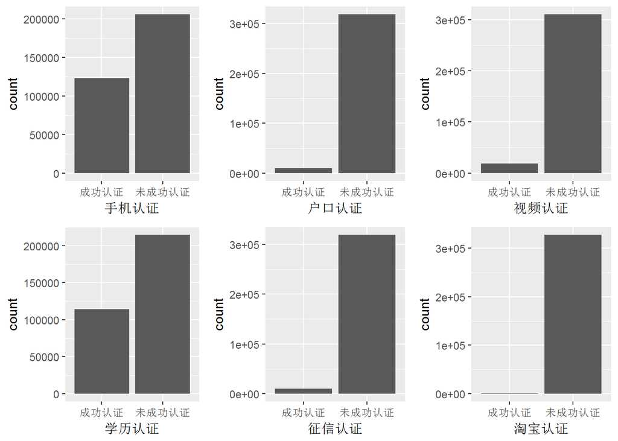

手机认证，户口认证，视频认证，学历认证，征信认证，淘宝认证这六个数据维度出现了大量未成功认证用户。考虑到这几项信息涉及隐私，推测出现此现象的原因为：一、此认证信息非必填项；二、用户为了保护隐私。所以这六个数据维度不能反映真实情况，对于分析用户特征无统计意义。

## 年龄分布

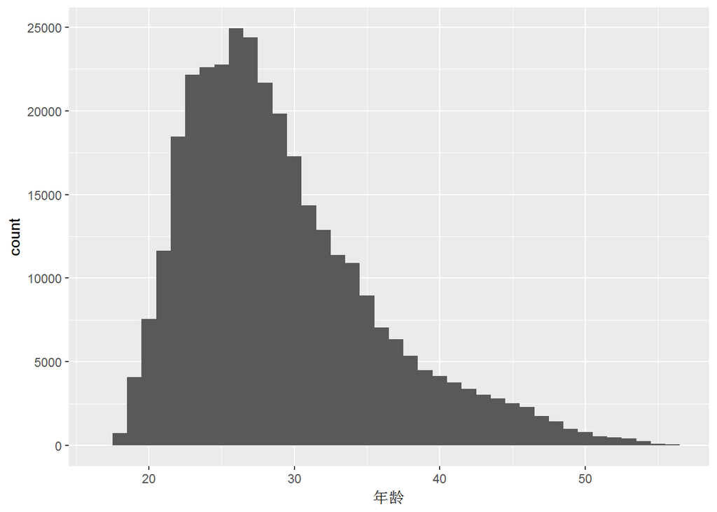

```
##    Min. 1st Qu.  Median    Mean 3rd Qu.    Max.
##   17.00   24.00   28.00   29.14   33.00   56.00
```

年龄呈轻微右偏分布，大部分用户年龄集中在24-33岁。

## 性别分布

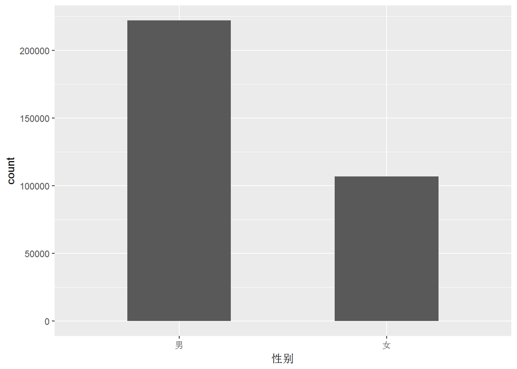

```
##     男     女
## 221946 106607
```

贷款用户的性别比例:男性是女性的2倍。

## 借款金额分布

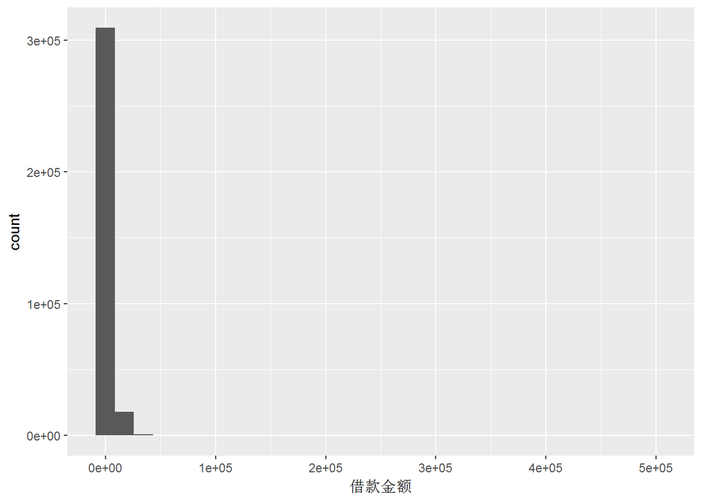

```
##    Min. 1st Qu.  Median    Mean 3rd Qu.    Max.
##     100    2033    3397    4424    5230  500000
```

借款金额出现了异常分布，最大值500000元，远大于大部分标的借款金额区间2033元-5230元。严重影响了对借款金额分布的观察。 虽然此处无充分理由证明借款金额=500000元为记录错误，但在分析数据时，可使用0.99百分位数将其排除，以便能更清晰显示数据分布。

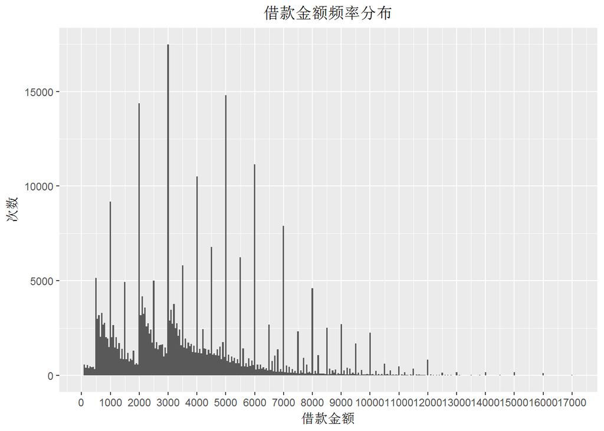

## 借款期限分布

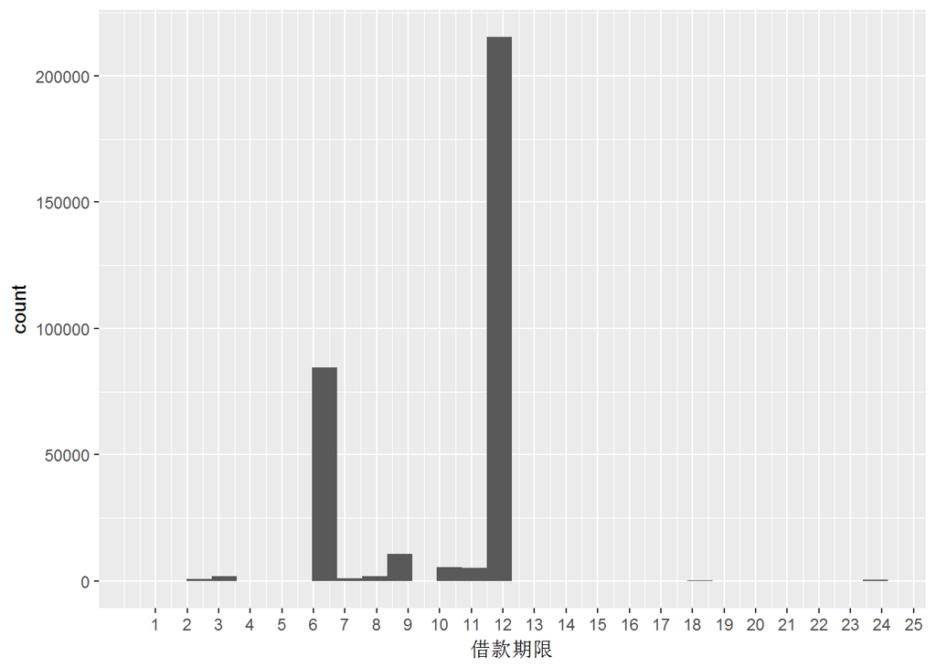

```
##    Min. 1st Qu.  Median    Mean 3rd Qu.    Max.
##    1.00    6.00   12.00   10.21   12.00   24.00
```

91%的用户倾向于贷款6期或者12期。用户更多的是解决燃眉之急。

## 借款利率分布

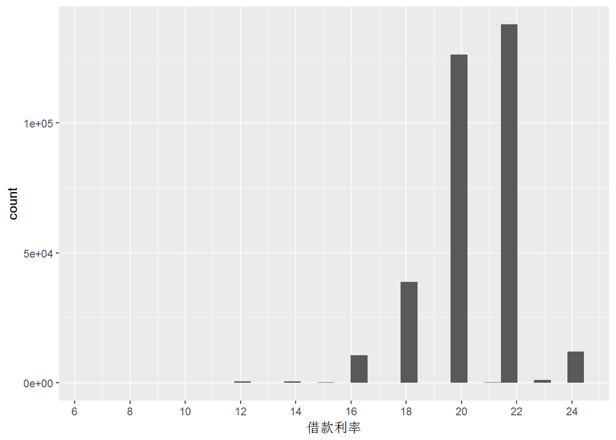

80%标的的借款利率在20%或22%。

## 借款类型分布

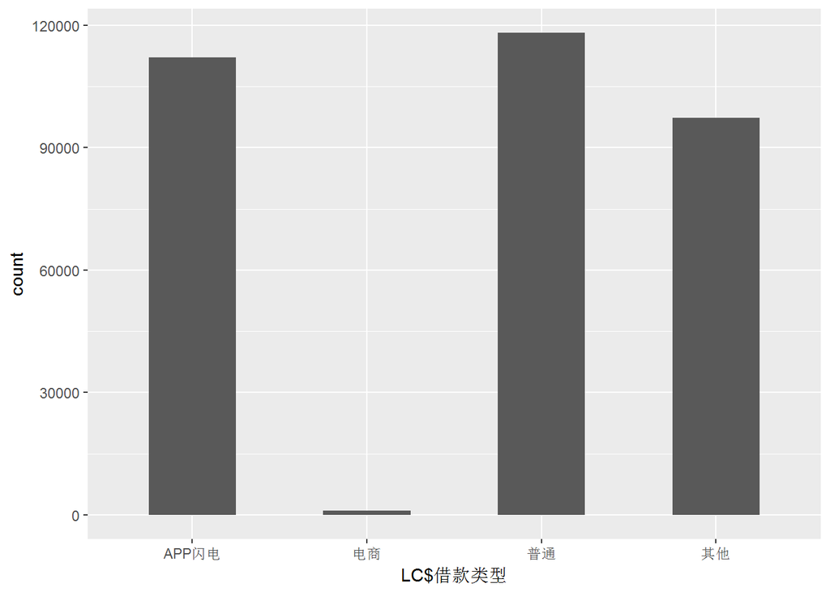

```
## APP闪电    电商    普通    其他
##  112079    1069  118103   97302
```

36%的用户选择‘普通’借款类型。34%的用户选择‘APP闪电’借款类型。小于1%的用户选择‘电商’借款类型。

## 每期还款分布

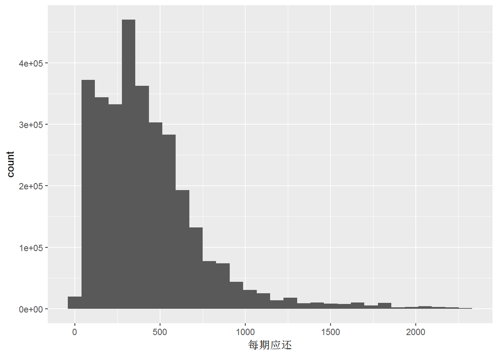

```
##     Min.  1st Qu.   Median     Mean  3rd Qu.     Max.
##      0.0    209.3    370.5    502.8    561.6 518750.0
```

用户更倾向于借款的每期还款在210-560元范围。

## 年龄对借款金额影响

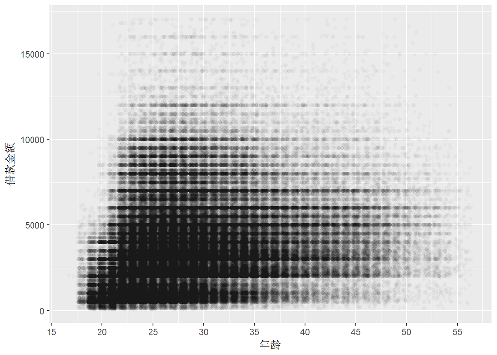

跟预期一样，25岁-30岁借款金额较其他年龄段大。17岁-24岁借款金额随年龄增加逐渐增大，31岁-56岁借款金额随年龄增加逐渐减少。对资金需求做大的人群在25岁-30岁，此阶段人群大部分工作不久，生活依靠自己，资金相对紧缺。

## 性别对借款金额影响

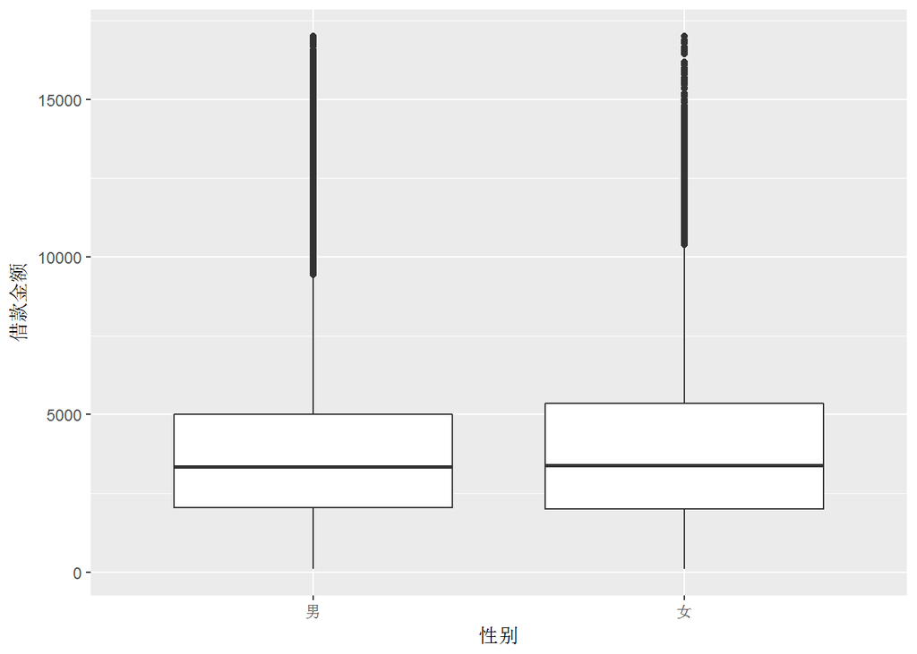

性别与借款金额无明显关系。

## 新老用户借款次数对比

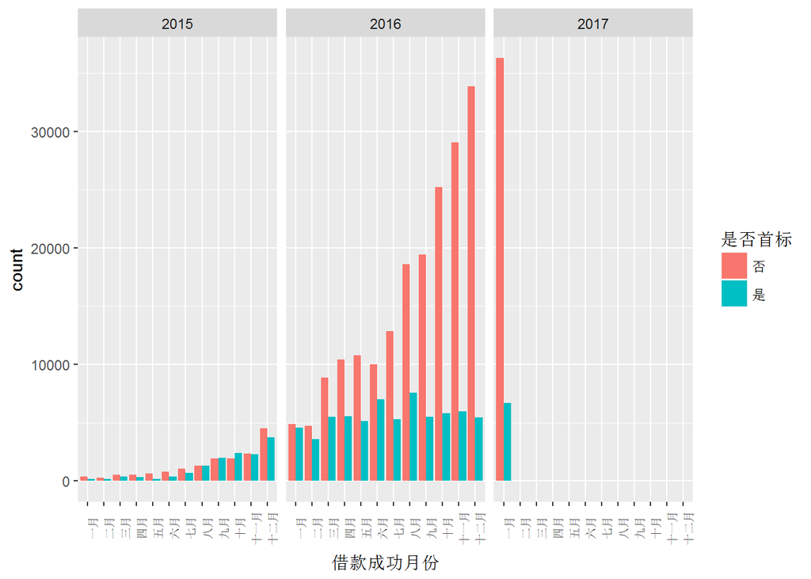

新用户借款次数在2016年1月之后比较稳定，月均5000次左右，老用户借款次数逐渐递增，从2016年1月的月均5000次增加到2017年1月的月均30000次左右。